# Financial Wellness

Faith Benamy & Cheikhou Kane

9/18/2019

The unfunded obligations of the pension and Other Post-Employment Benefits (OPEB) plans sponsored by local governments in the United States continue to grow. In the following report, we study in detail the financial obligations of 5 major US cities: Boston, Jacksonville, Los Angeles, Minneapolis and New York. We report on both their own measurements of their obligations, and how these differ from valuations using more realistic assumptions.

At the end of the 2017 fiscal year, the following cities reported unfunded liabilities of over 112 billions USD: 16.3 billions for pensions, $96 billions for OPEB.

**I. Rankings**

In the following section, we showcase different ways of ranking cities with respect to their financial obligations. First, we compare them using reported values then using values calculated with more realistic assumptions.

**1. Reported Value Rankings**

Using reported values, we rank cities according to: the grand total of their financial obligations, the share of revenue used for benefit payments (OPEB only), and finally the financial obligation scaled by population size.

**Financial Obligations Grand Total**

Given the skewness of the data, we decided to present the reported total of the unfunded obligations using a logarithmic scale as well.

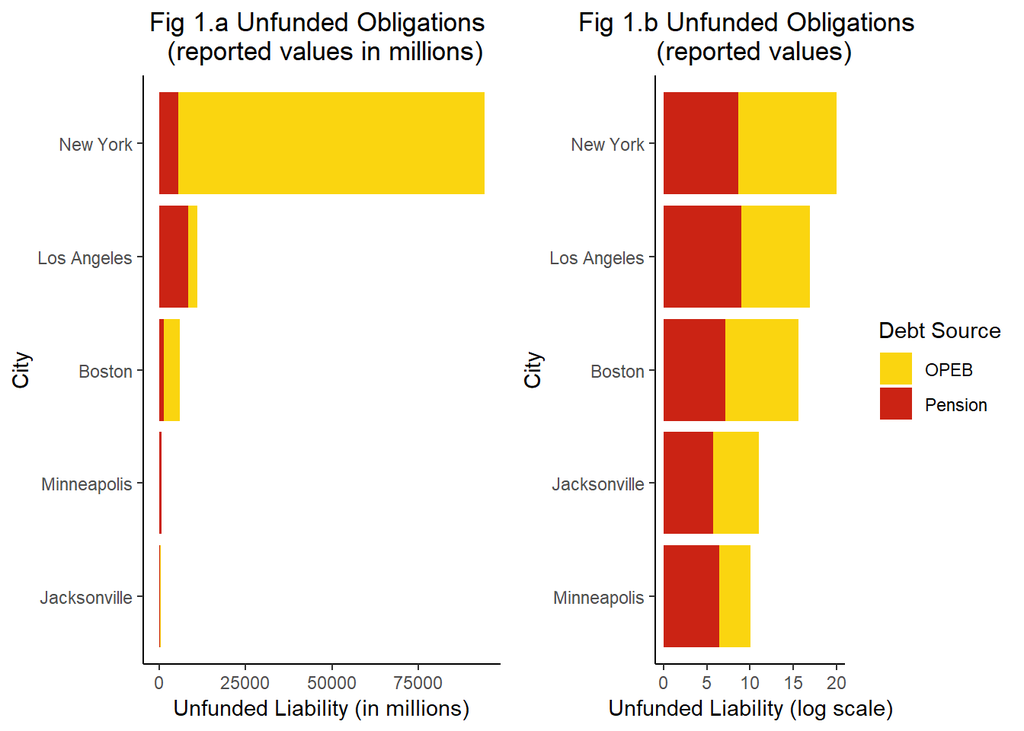

**OPEB benefit payment as share of revenue**

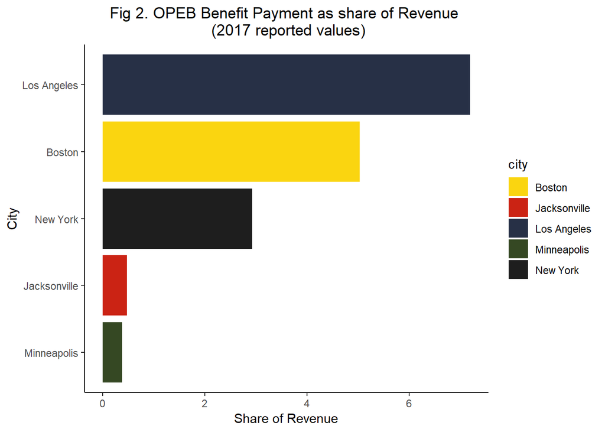

**Total Obligation per capita**

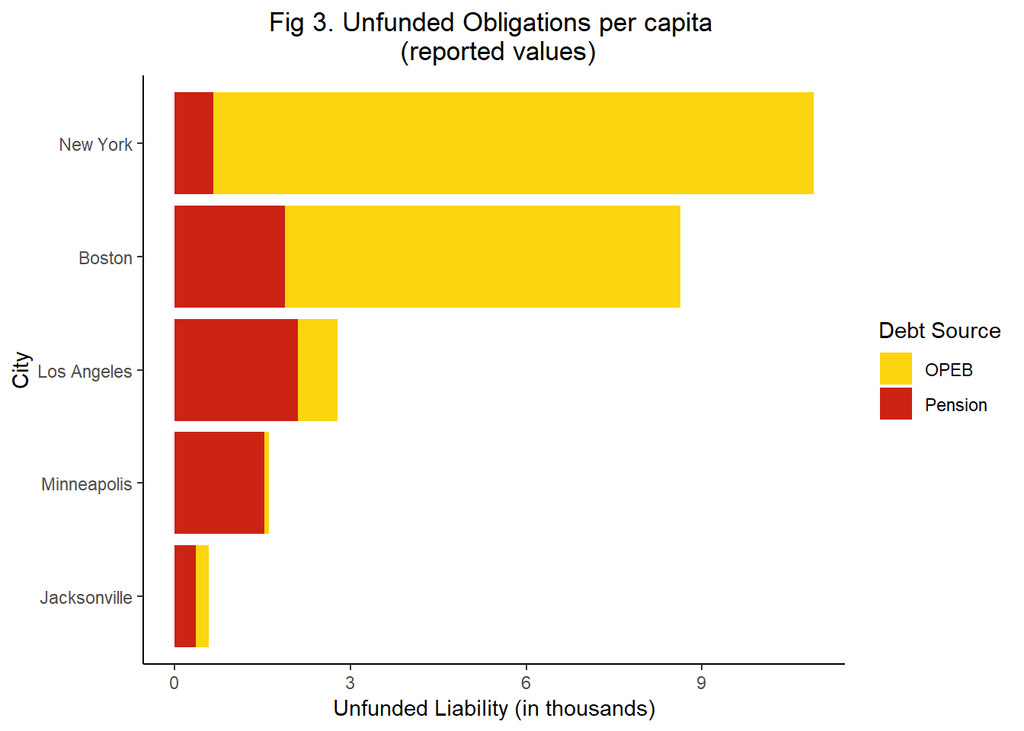

**2. Calculated Values Rankings**

Using calculated values, we rank cities according to the grand total of their financial obligations and the financial obligation scaled by population size. For OPEB, we calculate the Unfunded actuarial liability of each city with the AA corporate rate (4.03%) as the discount rate and a 15 year amortization period.

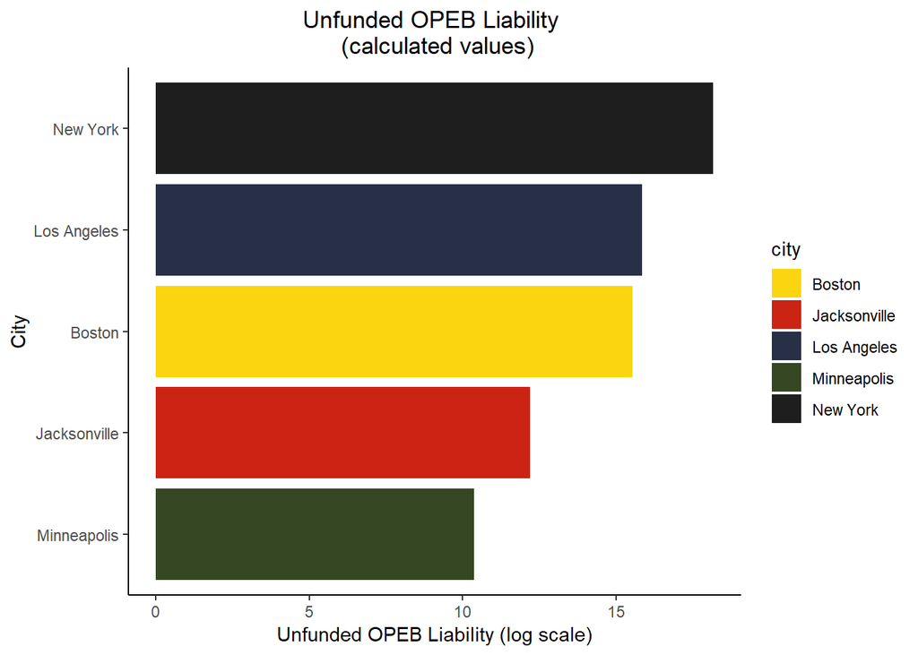

**Obligations per capita**

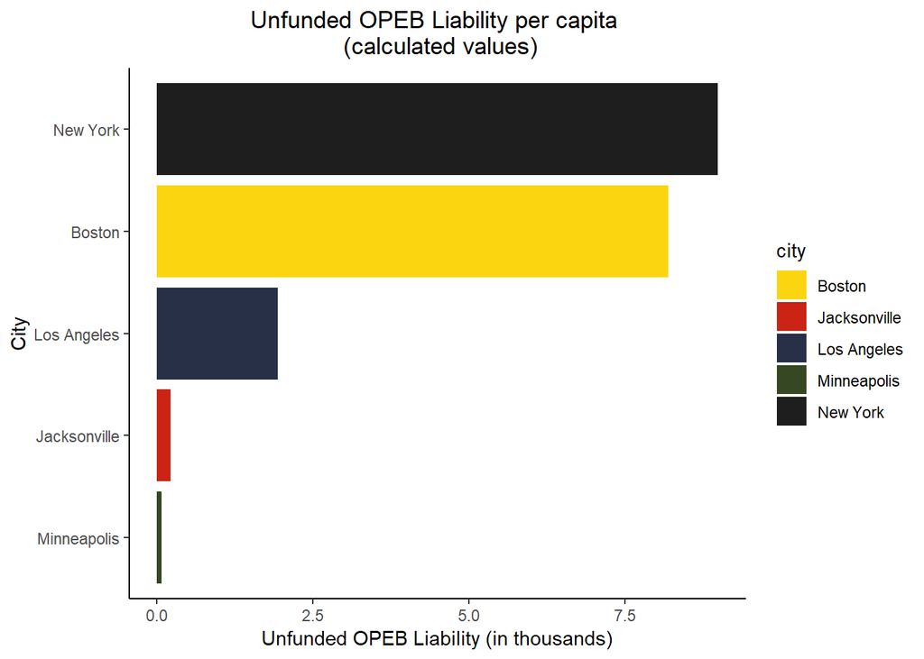

**II. Case Study: Los Angeles**

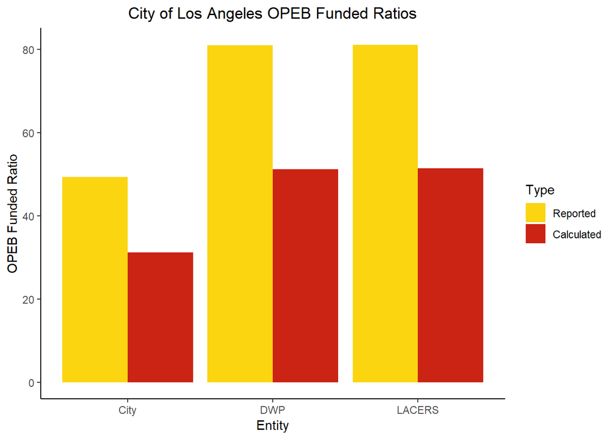